# FML_Assignment1_Urooj

2023-09-08

#1. The dataset used in this Assignment is PayEquity.

#2.The data is imported from https://github.com/davidcaughlin/R-Tutorial-Data-Files/blob/master/PayEquity.csv

```r
#install.packages("readr")    #"readr" package is installed to read the files
library(readr)                #library is used to load the package
setwd("C:\\Users\\user\\Desktop\\Masters\\Assignments\\FML Assignments\\Urooj_FML_Assignment")
read.csv(file="PayEquity.csv",header=TRUE,sep=",") #raw data file is imported using the                                                        read.csv function
```

[output not shown]

[output cut: 237 more lines]

```r
Data<-read.csv(file="PayEquity.csv",header=TRUE,sep=",") #The imported file is assigned to                                                           a Data frame "Data"
View(Data)                    #View function is used to display the data
head(Data,5)                  # Used to find the 5 rows from data
```

```
##    emp_id    job_title pay_grade    status base_pay job_tenure pay_grade_tenure
## 1 ee20097 technician 1       e07 nonexempt    51179        4.7             11.0
## 2 ee20032 technician 1       e07 nonexempt    46039        2.0              2.0
## 3 ee20050 technician 1       e07 nonexempt    50414        3.2              3.2
## 4 ee20019 technician 2       e07 nonexempt    56442        4.5              6.6
## 5 ee20026 technician 2       e07 nonexempt    57211        8.1              9.0
##   org_tenure  age educ perf    sex  race data_retrieval_date
## 1       13.4 44.8    1  9.4 female asian          2019-04-01
## 2        2.0 32.6    3  9.6 female black          2019-04-01
## 3        3.2 38.5    1  9.6 female asian          2019-04-01
## 4       10.9 31.5    4 10.0 female black          2019-04-01
## 5       10.1 34.7    4  3.4 female white          2019-04-01
```

#3.Descriptive statistics for a selection of quantitative and categorical variables

#3(a)Quantitative variable

```r
#install.packages("modeest")
library(modeest)         #estimating mode of distribution
summary(Data$job_tenure) #provides with min, max,mean,median and quartiles of attribute
```

```
##    Min. 1st Qu.  Median    Mean 3rd Qu.    Max.
##   0.200   3.700   5.200   5.199   6.900  11.400
```

```r
mean(Data$job_tenure)    #calculates the average
```

```
## [1] 5.1992
```

```r
median(Data$job_tenure)  #calculates the mid value
```

```
## [1] 5.2
```

```r
mfv(Data$job_tenure)     #most frequent value function is used to calculate mode
```

```
## [1] 5.6 7.2
```

```r
table(Data$job_tenure)   # table function shows all the values with its frequency
```

```
##
##  0.2  0.3  0.9  1.3  1.4  1.5  1.6    2  2.2  2.3  2.4  2.5  2.6  2.7  2.8    3
##    1    1    1    1    1    2    1    2    1    1    1    1    2    1    4    1
##  3.1  3.2  3.3  3.4  3.5  3.7  3.8  3.9  4.1  4.2  4.3  4.4  4.5  4.6  4.7  4.8
##    1    2    3    2    1    3    3    2    2    3    2    2    1    2    2    1
##    5  5.1  5.2  5.4  5.5  5.6  5.7  5.8    6  6.1  6.2  6.3  6.4  6.5  6.7  6.9
##    4    2    3    3    1    5    2    4    2    3    1    3    4    1    1    3
##    7  7.2  7.3  7.4  7.5  7.6  7.8  8.1  8.2  8.5  9.5  9.7  9.8   10 10.1 11.4
##    4    5    1    3    1    1    4    1    1    1    2    1    1    1    1    1
```

```r
sd(Data$job_tenure)      # calculates the standard deviation
```

```
## [1] 2.216088
```

```r
var(Data$job_tenure)     # calculates the Variance
```

```
## [1] 4.911048
```

```r
length(Data$job_tenure)  # calculates the number of rows in column
```

```
## [1] 125
```

```r
quantile(Data$job_tenure)# calculates the quantile
```

```
##   0%  25%  50%  75% 100%
##  0.2  3.7  5.2  6.9 11.4
```

```r
range(Data$job_tenure)   # range calculates the min and max values
```

```
## [1]  0.2 11.4
```

```r
sum(Data$job_tenure)     # calculates the sum of column values
```

```
## [1] 649.9
```

```r
min(Data$job_tenure)     # calculates the minimum value in column
```

```
## [1] 0.2
```

```r
max(Data$job_tenure)     # calculates the maximum value in column
```

```
## [1] 11.4
```

```r
sort(Data$job_tenure)    # ascending order
```

```
##   [1]  0.2  0.3  0.9  1.3  1.4  1.5  1.5  1.6  2.0  2.0  2.2  2.3  2.4  2.5  2.6
##  [16]  2.6  2.7  2.8  2.8  2.8  2.8  3.0  3.1  3.2  3.2  3.3  3.3  3.3  3.4  3.4
##  [31]  3.5  3.7  3.7  3.7  3.8  3.8  3.8  3.9  3.9  4.1  4.1  4.2  4.2  4.2  4.3
##  [46]  4.3  4.4  4.4  4.5  4.6  4.6  4.7  4.7  4.8  5.0  5.0  5.0  5.0  5.1  5.1
##  [61]  5.2  5.2  5.2  5.4  5.4  5.4  5.5  5.6  5.6  5.6  5.6  5.6  5.7  5.7  5.8
##  [76]  5.8  5.8  5.8  6.0  6.0  6.1  6.1  6.1  6.2  6.3  6.3  6.3  6.4  6.4  6.4
##  [91]  6.4  6.5  6.7  6.9  6.9  6.9  7.0  7.0  7.0  7.0  7.2  7.2  7.2  7.2  7.2
## [106]  7.3  7.4  7.4  7.4  7.5  7.6  7.8  7.8  7.8  7.8  8.1  8.2  8.5  9.5  9.5
## [121]  9.7  9.8 10.0 10.1 11.4
```

```r
sort(Data$job_tenure, decreasing=TRUE)# descending order
```

```
##   [1] 11.4 10.1 10.0  9.8  9.7  9.5  9.5  8.5  8.2  8.1  7.8  7.8  7.8  7.8  7.6
##  [16]  7.5  7.4  7.4  7.4  7.3  7.2  7.2  7.2  7.2  7.2  7.0  7.0  7.0  7.0  6.9
##  [31]  6.9  6.9  6.7  6.5  6.4  6.4  6.4  6.4  6.3  6.3  6.3  6.2  6.1  6.1  6.1
##  [46]  6.0  6.0  5.8  5.8  5.8  5.8  5.7  5.7  5.6  5.6  5.6  5.6  5.6  5.5  5.4
##  [61]  5.4  5.4  5.2  5.2  5.2  5.1  5.1  5.0  5.0  5.0  5.0  4.8  4.7  4.7  4.6
##  [76]  4.6  4.5  4.4  4.4  4.3  4.3  4.2  4.2  4.2  4.1  4.1  3.9  3.9  3.8  3.8
##  [91]  3.8  3.7  3.7  3.7  3.5  3.4  3.4  3.3  3.3  3.3  3.2  3.2  3.1  3.0  2.8
## [106]  2.8  2.8  2.8  2.7  2.6  2.6  2.5  2.4  2.3  2.2  2.0  2.0  1.6  1.5  1.5
## [121]  1.4  1.3  0.9  0.3  0.2
```

```r
IQR(Data$job_tenure)     # calculates the InterQuartile Range
```

```
## [1] 3.2
```

```r
xtabs(~sex+race,data=Data)# Display value in cross tab
```

```
##         race
## sex      asian black white
##   female    20    32    20
##   male       5    27    21
```

#3(b)Categorical variable

```r
table(Data$race)  # table function is used to count the frequency of each categorical value
```

```
##
## asian black white
##    25    59    41
```

```r
prop.table(table(Data$race))*100 #calculates the proportion of different categories
```

```
##
## asian black white
##  20.0  47.2  32.8
```

```r
mfv(Data$race)    # most frequent value function is used to find the highest frequent categorical value in a column
```

```
## [1] "black"
```

```r
unique(Data$race) # Unique function is used to  find the unique values in a column by removing the duplicates
```

```
## [1] "asian" "black" "white"
```

#4 Transforming a Quantitative Variable-Zscore, Square root

```r
#install.packages("ggplot2") # ggplot2 package is used to visualize data and plot the charts
library(ggplot2)            # ggplot2 is loaded to use for graphs
#install.packages("gridExtra")#gridExtra is used as an extension for grids
library(gridExtra)           # gridExtra is loaded for grids

#z-score
z=(Data$pay_grade_tenure-mean(Data$pay_grade_tenure))/sd(Data$pay_grade_tenure) #calculating the z score
z # The variable will give the output of zscore formula assigned to z
```

```
##   [1]  0.536500306 -1.844418211 -1.526962409 -0.627504302  0.007407302
##   [6] -0.310048500 -1.368234508  0.139680553 -1.500507759 -0.521685702
##  [11] -1.156597306  0.271953804  0.219044504 -0.124865949 -1.897327512
##  [16]  0.351317755  2.017960716 -1.368234508  1.435958412 -0.786232204
##  [21] -1.738599610 -0.468776401 -0.548140352 -0.944960105  0.853956108
##  [26] -1.288870557  1.171411910 -0.389412451 -0.019047348  0.562954956
##  [31] -0.098411299  0.986229359 -0.415867101 -0.442321751  0.086771253
##  [36] -1.685690310  1.409503762  0.562954956  1.171411910 -0.892050804
##  [41]  1.515322363 -1.315325207  1.462413062 -1.209506607  1.303685161
##  [46]  0.774592158 -0.627504302  0.298408454  1.277230511 -1.474053109
##  [51] -0.495231052  0.615864256 -0.521685702 -0.045501998 -0.310048500
##  [56] -0.045501998 -1.579871709 -1.844418211 -0.521685702 -0.733322903
##  [61] -0.812686854 -1.130142656 -0.336503150  0.562954956  0.562954956
##  [66]  0.880410758  1.224321211  0.589409606 -0.151320599 -0.098411299
##  [71] -1.024324055  1.039138659  1.144957260  1.594686313  0.139680553
##  [76] -0.733322903 -0.601049652  0.139680553  1.039138659 -0.230684550
##  [81] -0.812686854 -0.336503150  1.912142116  0.113225903  0.695228207
##  [86]  2.414780469  0.933320059 -1.024324055 -1.791508911  1.806323515
##  [91]  1.700504914 -0.468776401  1.065593310 -0.521685702  0.298408454
##  [96]  1.753414215 -1.712144960 -0.442321751 -0.204229899  0.271953804
## [101]  0.510045656  1.224321211 -1.262415907 -0.019047348  0.271953804
## [106]  0.430681705 -0.204229899 -1.024324055  1.250775861  0.219044504
## [111]  0.377772405  1.197866561  1.065593310  0.060316602  1.488867713
## [116] -0.310048500  1.356594462 -0.468776401  0.404227055 -0.706868253
## [121] -0.362957801 -0.124865949  0.192589853 -1.500507759  0.139680553
```

```r
#Square root
Sqrvar<-sqrt(Data$pay_grade_tenure) # sqrt function applies square root to each value in the column
Sqrvar # The variable will give the output of square root formula assigned to Sqrvar
```

```
##   [1] 3.316625 1.414214 1.788854 2.569047 3.000000 2.792848 1.949359 3.082207
##   [9] 1.816590 2.645751 2.144761 3.162278 3.130495 2.915476 1.341641 3.209361
##  [17] 4.074310 1.949359 3.794733 2.449490 1.549193 2.683282 2.626785 2.323790
##  [25] 3.492850 2.024846 3.660601 2.738613 2.983287 3.331666 2.932576 3.563706
##  [33] 2.720294 2.701851 3.049590 1.612452 3.781534 3.331666 3.660601 2.366432
##  [41] 3.834058 2.000000 3.807887 2.097618 3.728270 3.449638 2.569047 3.178050
##  [49] 3.714835 1.843909 2.664583 3.361547 2.645751 2.966479 2.792848 2.966479
##  [57] 1.732051 1.414214 2.645751 2.489980 2.428992 2.167948 2.774887 3.331666
##  [65] 3.331666 3.507136 3.687818 3.346640 2.898275 2.932576 2.258318 3.591657
##  [73] 3.646917 3.872983 3.082207 2.489980 2.588436 3.082207 3.591657 2.846050
##  [81] 2.428992 2.774887 4.024922 3.065942 3.405877 4.254409 3.535534 2.258318
##  [89] 1.483240 3.974921 3.924283 2.683282 3.605551 2.645751 3.178050 3.949684
##  [97] 1.581139 2.701851 2.863564 3.162278 3.301515 3.687818 2.049390 2.983287
## [105] 3.162278 3.255764 2.863564 2.258318 3.701351 3.130495 3.224903 3.674235
## [113] 3.605551 3.033150 3.820995 2.792848 3.754997 2.683282 3.240370 2.509980
## [121] 2.756810 2.915476 3.114482 1.816590 3.082207
```

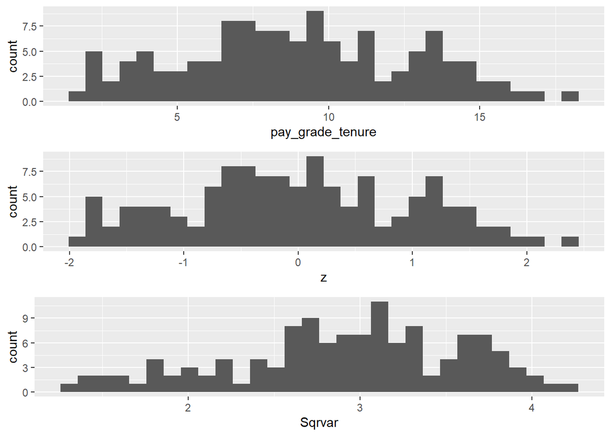

```r
# to plot a histogram with pay_grade_tenure column ggplot is used and assigned to Var1 variable
Var1<- ggplot(data= Data, aes(x= pay_grade_tenure)) + geom_histogram()

# to plot a histogram with zscore (Z column) ggplot is used and assigned to Var2 variable
Var2<- ggplot(data= Data, aes(x= z)) + geom_histogram()

# to plot a histogram with square root (Sqrvar column) ggplot is used and assigned to Var3 variable
Var3<- ggplot(data= Data, aes(x= Sqrvar)) + geom_histogram()

# grid arrange is used to assemble the multiple plots in a page either in rows or columns specified
grid.arrange(Var1, Var2, Var3, ncol=1)
```

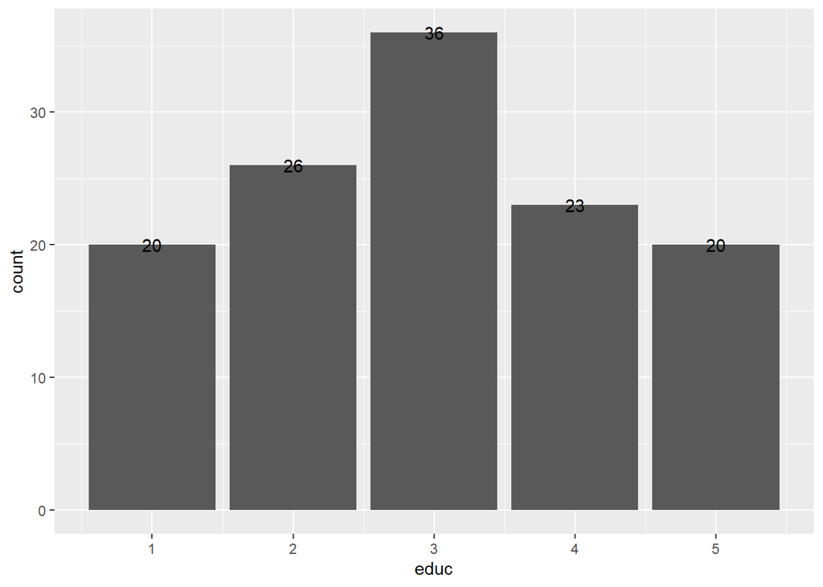

```r
library(ggplot2)
ggplot(Data, aes(x = educ)) + geom_bar(stat = "count") + stat_count(geom = "text", aes(label = after_stat(count)), na.rm = TRUE) # a bar graph is plotted using ggplot function, x axis as "educ" column and y as count of "educ" by providing data values and labels for bars
```

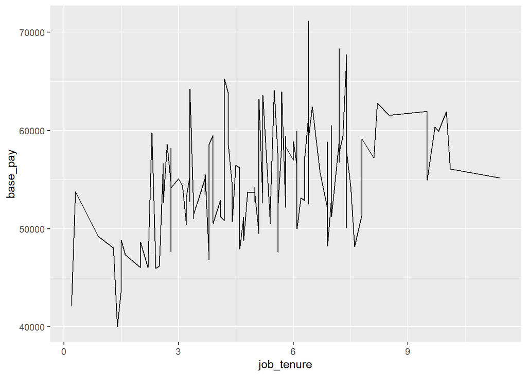

```r
ggplot(data = Data, aes(x = job_tenure, y = base_pay)) + geom_line()
```

#The above graph depicts the summary of base pay trends based on the job tenure. As the job tenure increases, the base pay trends are increasing.